# Pseudotime All Cells

Gametocyte Development in *Plasmodium berghei

[Andrew Russell](https://ajcrussell.wixsite.com/mysite/about)

November 10, 2020

# 1. Introduction and Aims

We have merged the two datasets together in GCSKO_merge.Rmd. Here, we will perform pseudotime analysis on the dataset and build modules of genes that show similar expression across this pseudotime.

# 2. Read in the data

## Load/Install the Required Packages

```
[1] "patchwork is loaded correctly"
[1] "viridis is loaded correctly"
```

```
[1] "Seurat is loaded correctly"
```

```
[1] "cowplot is loaded correctly"
```

```
[1] "gridExtra is loaded correctly"
```

```
[1] "grid is loaded correctly"
```

```
[1] "Hmisc is loaded correctly"
```

```
[1] "reshape2 is loaded correctly"
```

```
[1] "dplyr is loaded correctly"
```

```
[1] "ggnewscale is loaded correctly"
```

```
[1] "monocle3 is loaded correctly"
```

## load data

tenx.mutant.integrated is needed from the merge script

```r
## load dataset
tenx.mutant.integrated <- readRDS("../data_to_export/tenx.mutant.integrated.RDS")
```

# 3. Pseudotime Analysis Using Monocle

For monocle input, we can use all WT cells, provided we correct for batch effects.

https://cole-trapnell-lab.github.io/monocle3/docs/differential/

We have 5 potential sources of WT information:

1. 10X - 5k run
2. SS2 - WT cells in this experiment
3. SS2 - 10X (published)
4. 10X - MCA (published)
5. 10X - 30k run

When you try and use 1 and 2 together, there are issues with calling modules. I think this is to do with the integration that Seurat does, so since the 10X data is complete (i.e. covers the lifecycle), we will sacrifice some extra power (a few more cells) so that we can call more modules.

## Pseudotime calculation

### Preprocess

```r
## extract data
## this extracts wt only cells
#wt_cells <- rownames(tenx.mutant.integrated@meta.data[which(tenx.mutant.integrated@meta.data$identity_combined == "WT" | tenx.mutant.integrated@meta.data$identity_combined == "WT_10X"),])

## extracts only 10x cells
wt_cells <- rownames(tenx.mutant.integrated@meta.data[which(tenx.mutant.integrated@meta.data$identity_combined == "WT_10X"),])

## make a new Seurat of this
seurat.object <-subset(tenx.mutant.integrated, cells = wt_cells)

## check that this is the same as the pb_sex_filtered object
#data_test <- as(as.matrix(GetAssayData(pb_sex_filtered, assay = "RNA", slot = "data")), 'sparseMatrix')
#is.equal
#is.identical

## extract counts and pheno:
## the reason we use the integrated and then subsetted is because these cells have been normalised whereas the cells in pb_sex_filtered have not been normalised (well they have but with doublets in them)
data <- as(as.matrix(GetAssayData(seurat.object, assay = "RNA", slot = "data")), 'sparseMatrix')
## make phenodata
pd <- data.frame(seurat.object@meta.data)
## keep only the columns that are relevant in metadata
#pData <- pd %>% select(orig.ident, nCount_RNA, nFeature_RNA)
## make gene metadata
fData <- data.frame(gene_short_name = row.names(data), row.names = row.names(data))

## Construct monocle cds
monocle.object <- new_cell_data_set(expression_data = data, cell_metadata = pd, gene_metadata = fData)

## preprocess
monocle.object = preprocess_cds(monocle.object, num_dim = 50, norm_method = "none")
### if using integrated data:
# norm_method = "none", alignment_group = "~ experiment"

## plot jack straw plot
#plot_pc_variance_explained(monocle.object)

#monocle.object = reduce_dimension(monocle.object, reduction_method = "UMAP", preprocess_method = "PCA", umap.metric = "euclidean", umap.n_neighbors = 50, umap.min_dist = 0.5, verbose = FALSE)

#plot_cells(monocle.object, color_cells_by="experiment")
```

### Graph Learning

```r
## add UMAP from Seurat
monocle.object@int_colData@listData$reducedDims@listData[["UMAP"]] <- seurat.object@reductions[["DIM_UMAP"]]@cell.embeddings

## cluster
## this is essential to run the learn_graph function later on
monocle.object = cluster_cells(monocle.object)

## plot initial clustering by monocle
#plot_cells(monocle.object, color_cells_by="cluster", group_cells_by="partition", x = 2, y = 1)

## map pseudotime
monocle.object = learn_graph(monocle.object, learn_graph_control=list(ncenter=300), use_partition = FALSE)
# learn_graph_control=list(ncenter=500) - play with this parameter

## Plot cells
plot_cells(monocle.object, color_cells_by="partition", group_cells_by="partition", x = 2, y = 1)
```

### Pseudotime Calculation

```r
## a helper function to identify the root principal points:
get_earliest_principal_node <- function(cds, time_bin="4"){
  cell_ids <- which(colData(cds)[, "seurat_clusters"] == time_bin)
  closest_vertex <-
  cds@principal_graph_aux[["UMAP"]]$pr_graph_cell_proj_closest_vertex
  closest_vertex <- as.matrix(closest_vertex[colnames(cds), ])
  root_pr_nodes <-
  igraph::V(principal_graph(cds)[["UMAP"]])$name[as.numeric(names
  (which.max(table(closest_vertex[cell_ids,]))))]

  root_pr_nodes
}

## Order the cells and caclulate pseudotime
#monocle.object = order_cells(monocle.object, root_pr_nodes=get_earliest_principal_node(monocle.object))
monocle.object = order_cells(monocle.object)

## Plot
plot_cells(monocle.object, color_cells_by = "pseudotime", label_cell_groups=FALSE, cell_size = 2, x = 2, y = 1) +
  coord_fixed() +
  theme_void() +
  labs(title = "Pseudotime") +
  theme(plot.title = element_text(hjust = 0.5))
```

### Module Construction

```r
## find genes that change as a function of pt:
monocle.object_pr_test_res <- graph_test(monocle.object, neighbor_graph="principal_graph", cores=8)

## find significant genes
pr_deg_ids <- row.names(subset(monocle.object_pr_test_res, q_value < 0.05))

## collect into modules
gene_module_df <- find_gene_modules(monocle.object[pr_deg_ids,], resolution=c(10^seq(-6,2)))

## how many genes in modules?
dim(gene_module_df)
```

## Module Information

Which module do the mutant genes belong to?

```r
## create a list of our mutant gene IDs
list_of_mutant_genes <- c("PBANKA-0828000", "PBANKA-1302700", "PBANKA-1447900", "PBANKA-0102400", "PBANKA-0716500", "PBANKA-1435200", "PBANKA-1418100", "PBANKA-1144800", "PBANKA-0902300", "PBANKA-0413400", "PBANKA-1454800")

## make a dataframe to convert the gene IDs into actual IDs
df_mutant_ids <- as.data.frame(unique(cbind(tenx.mutant.integrated@meta.data$identity_gene_updated, tenx.mutant.integrated@meta.data$identity_updated)))[-c(1, 3),]
# remove the "820" bit on 10
df_mutant_ids$V1 <- gsub("_820", "", df_mutant_ids$V1)
# change the underscore (_) to a dash (-) in gene IDs
df_mutant_ids$V1 <- gsub("_", "-", df_mutant_ids$V1)
names(df_mutant_ids) <- c("gene_ID", "mutant_identity")

## subset modules df to include only mutant gene IDs
df_mutant_gene_modules <- as.data.frame(gene_module_df[which(gene_module_df$id %in% list_of_mutant_genes),])
names(df_mutant_gene_modules)[1] <- "gene_ID"

## merge dataframes
df_mutant_gene_modules <- merge(df_mutant_gene_modules, df_mutant_ids, by = "gene_ID")

## Inspect
df_mutant_gene_modules
```

The modules of interest are therefore:

```r
table(df_mutant_gene_modules$module)
```

Which modules do other genes of interest lie in?:

```r
## landmark genes (genes of interest)
# AP2G - PBANKA-1437500
# AP2 - PBANKA-0909600 - from poran paper
# AP2G-2 - PBANKA-1034300
# PBANKA-1319500 - CCP2 - female 820
# PBANKA-0416100 - MG1 - male 820
# PBANKA-0831000 - MSP1 - late asexual
# PBANKA-1102200 - MSP8 - early asexual (from Bozdech paper)

## create a list of landmark genes
list_of_landmark_genes <- c("PBANKA-1437500", "PBANKA-0909600","PBANKA-1034300", "PBANKA-1319500", "PBANKA-0416100", "PBANKA-0831000", "PBANKA-1102200")

## make dataframe
df_landmark_gene_modules <- gene_module_df[which(gene_module_df$id %in% list_of_landmark_genes),]

## inspect
df_landmark_gene_modules
```

## Plotting

plot out modules

```r
## make aggregated df again so you can edit it
agg_mat <- aggregate_gene_expression(monocle.object, gene_module_df, cell_group_df)

## h clust the aggregated matrix
module_dendro <- hclust(dist(agg_mat))

## use these clusters to reorder the modules
gene_module_df$module <- factor(gene_module_df$module, levels = row.names(agg_mat)[module_dendro$order])

## plot
plot_cells(monocle.object, genes=gene_module_df %>% filter(module %in% c(1:20)),
           cell_size = 2,
           x = 2, y = 1,
           label_cell_groups=FALSE,
           scale_to_range = TRUE,
                          show_trajectory_graph=FALSE,
                          group_label_size = 15) +
                          scale_colour_viridis_c(name = "expression", option = "C", alpha = 1) +
                          coord_fixed() +
                          theme_void() +
                          theme(legend.position = "bottom")
```

Make a dataframe to plot

```r
## make cell group df
cell_group_df <- tibble::tibble(cell=row.names(colData(monocle.object)), cell_group=colData(monocle.object)$seurat_clusters)

## make plotting df
agg_mat <- aggregate_gene_expression(monocle.object, gene_module_df, cell_group_df)
```

Find out how many genes there are per total so we can add this to the plot

```r
## how many genes per module?
genes_per_module <- as.data.frame(table(gene_module_df$module))
genes_per_module
```

```r
## prepare custom dataframe for all cells by modules:
agg_mat_no_group <- aggregate_gene_expression(monocle.object, gene_module_df)

## extract pseudotime values
monocle.object@colData$pt <- pseudotime(monocle.object, reduction_method = "UMAP")

## make an anotation
anno_no_group <- data.frame(monocle.object@colData$cluster_colours_figure, monocle.object@colData$pt, row.names = rownames(monocle.object@colData))
names(anno_no_group) <- c("sex", "Pseudotime")

## make annotation colours
annotation_colours <- list(sex = c(Male="#016c00", Female="#a52b1e", Bipotential = "#ffe400", Asexual = "#0052c5"),
                           Pseudotime = magma(12, direction = 1))

## change the order of the data frame
col.order <- rownames(anno_no_group[with(anno_no_group, order(sex, Pseudotime)), ])
agg_mat_no_group <- agg_mat_no_group[,col.order]

## plot
pheatmap::pheatmap(agg_mat_no_group,
                   #scale="row",
                   cluster_cols = FALSE,
                   clustering_method="complete",
                   show_colnames = FALSE,
                   annotation_col = anno_no_group,
                   annotation_colors = annotation_colours,
                   cutree_rows = 7)
```

### by cluster plot

Make annotations to add to the heatmap

```r
## change names for row names to include "module " at the beginning of them
row.names(agg_mat) <- stringr::str_c("Module ", row.names(agg_mat))

## add number of cells to the rownames for the module
for(i in seq_along(genes_per_module$Freq)){
  row.names(agg_mat)[i] <- stringr::str_c(row.names(agg_mat)[i]," (n = " ,genes_per_module$Freq[i], ")")
}

## create annotation of clusters for heatmap
cluster_anno <- data.frame(cluster = unique(colData(monocle.object)$seurat_clusters))
row.names(cluster_anno) <- cluster_anno$cluster

## clusters were defined in the merge script earlier as:
male_clusters <- c("26", "22", "11", "17")
female_clusters <- c("30", "32", "27", "12", "13", "18")
asex_clusters <- c("7", "10", "9", "14", "1", "3", "4", "8", "5", "6", "2", "0", "16", "19", "28", "15", "21", "23", "24", "25", "31", "29", "33")
bipotential_clusters <- c("20")

## add identities to the column
cluster_anno$group <- NA
cluster_anno$group[which(cluster_anno$cluster %in% asex_clusters)] <- "Asexual"
cluster_anno$group[which(cluster_anno$cluster %in% male_clusters)] <- "Male"
cluster_anno$group[which(cluster_anno$cluster %in% female_clusters)] <- "Female"
cluster_anno$group[which(cluster_anno$cluster %in% bipotential_clusters)] <- "Committed"
cluster_anno <- cluster_anno[ , 2, drop = FALSE]
cluster_anno

## Make a df of meta data
## this is used later in the ridgeplots too
## extract pseudotime values
pt_values <- as.data.frame(pseudotime(monocle.object, reduction_method = "UMAP"))
pt_values$cell_name <- rownames(pt_values)
meta_data_df <- as.data.frame(monocle.object@colData)
meta_data_df$cell_name <- rownames(meta_data_df)
meta_data_df <- merge(meta_data_df, pt_values, by = "cell_name")
## the pt will be added to the last column so add the name pt to the merged df
names(meta_data_df)[length(names(meta_data_df))] <- "pt"

## add median pseudotime per cluster
## help was obtained here:https://stackoverflow.com/questions/54360855/calculate-mean-for-column-grouped-by-values-of-two-other-columns
## make subsetted dataframe with just cluster and pt
df_median_pt <- meta_data_df[ ,c("pt", "seurat_clusters")]
## apply across dataframe to get median
mean.df1 <- tapply(df_median_pt$pt, list(df_median_pt$seurat_clusters), median)
mean.df2 <- as.data.frame(as.table(mean.df1))
## rename cols
names(mean.df2) <- c("seurat_clusters", "pt_Median")
## rename rows
rownames(mean.df2) <- mean.df2$seurat_clusters
## to make each value have the mean in the original dataframe
#merge(df_median_pt, mean.df2)
## add to annotation dataframe
cluster_anno <- merge(cluster_anno, mean.df2, by=0)

## add rownames to dataframe
rownames(cluster_anno) <- cluster_anno$Row.names
## subset to have only info of interest
cluster_anno <- cluster_anno[,c(2,4)]
names(cluster_anno) <- c("Identity", "Median_Pseudotime_of_Cluster")
```

Plot

```r
## make annotation colours
annotation_colours <- list(Identity = c(Male="#016c00", Female="#a52b1e", Asexual= "#0052c5", Committed = "#f2eb23"),
                           Median_Pseudotime_of_Cluster = magma(12, direction = 1))

## reorder the levels
## make df of data
agg_mat_df <- as.data.frame(agg_mat)
## remove levels in my_levels that are not present here - i.e. clusters that are missing because they are not represented in the 10X data
## my_levels was defined in the merge script as the order we want to plot clusters in:
my_levels <- c(asex_clusters, bipotential_clusters, male_clusters, female_clusters)
## reorder the levels so you can plot the cluters as you wish
my_levels_10x_data <- my_levels[which(my_levels %in% colnames(agg_mat_df))]
## order the annotation
cluster_anno <- cluster_anno[(match(my_levels_10x_data, rownames(cluster_anno))), ]
## sort the values in the df
agg_mat_df <- agg_mat_df[ ,(match(my_levels_10x_data, colnames(agg_mat_df)))]

## plot heatmap
pheatmap::pheatmap(agg_mat_df,
                   scale="column",
                   cluster_cols = FALSE,
                   clustering_method="ward.D2",
                   annotation_col = cluster_anno,
                   annotation_colors = annotation_colours,
                   #gaps_col = c(28,29,37),
                   cutree_rows = 12) +
  theme(legend.position = "bottom")
```

```r
## subset aggregated matrix to take out problematic clusters 22, 42, (44 - alreayd removed as it doesn't have any 10x cells)
agg_mat_df_scaled_subset <- agg_mat_df_scaled[, -which(colnames(agg_mat_df_scaled) %in% c(22,42))]

## make df of data
agg_mat_df_scaled_subset_df <- as.data.frame(agg_mat_df_scaled_subset)
## remove levels in my_levels that are not present here - i.e. clusters that are missing because they are not represented in the 10X data
my_levels_10x_data_subset <- my_levels[which(my_levels %in% colnames(agg_mat_df_scaled_subset_df))]
## sort the values
agg_mat_df_scaled_subset <- agg_mat_df_scaled_subset[ ,(match(my_levels_10x_data_subset, colnames(agg_mat_df_scaled_subset)))]


## subset anno
cluster_anno_subset <- cluster_anno[-which(rownames(cluster_anno) %in% c(22,42)),]

## subset the annotation
## add annotation:
heatmap_annotation_subset <- HeatmapAnnotation(df = cluster_anno_subset,
                                        col = list(
Identity = c(Male="#016c00", Female="#a52b1e", Asexual= "#0052c5", Committed = "#f2eb23")),
                                        annotation_legend_param = list(Median_Pseudotime_of_Cluster = list(direction = "horizontal"), Identity = list(nrow = 1)))


library(ComplexHeatmap)
library(RColorBrewer)
modules_heatmap <- Heatmap(agg_mat_df_scaled_subset,
        column_order = NULL,
        clustering_method_rows = "ward.D2",
        bottom_annotation = heatmap_annotation_subset,
        col = colorRampPalette(rev(brewer.pal(n = 7, name =
  "RdYlBu")))(100),
        heatmap_legend_param = list(direction = "horizontal"))
draw(modules_heatmap, merge_legend = TRUE, heatmap_legend_side = "bottom",
    annotation_legend_side = "bottom")
```

```r
## save the gene modules in case you want to return to these later
modules_df_original_10x_data_set <- gene_module_df
```

It would be nice to include a measure of Psuedotime in the heatmap. We will first test the variance of Pseudotime in each cluster

```r
## redefine order of clusters:
meta_data_df$seurat_clusters <- factor(x = meta_data_df$seurat_clusters, levels = my_levels)

## plot
ggplot(meta_data_df, aes(x = pt, y = seurat_clusters, fill = stat(x))) +
  geom_density_ridges_gradient(scale = 3, rel_min_height = 0.01, jittered_points = TRUE, quantile_lines = TRUE, quantiles = 2, point_alpha = 0.5, alpha = 0.5) +
  scale_fill_viridis_c(name = "Pseudotime", option = "C") +
  labs(title = 'PT by Cluster') +
  theme_classic() +
  ## annotate males
  geom_hline(aes(yintercept = 37.5)) +
  ## annotate females
  geom_hline(aes(yintercept = 29.5)) +
  ## annotate hermaphrodite
  geom_hline(aes(yintercept = 28.5))
```

### module expression in mutants

Make a heatmap of module expression in mutants:

```r
## the aggregate_gene_expression function in Monocle is located here: https://github.com/cole-trapnell-lab/monocle3/blob/1a02274209c765fe7a60f533a31b1da3dacf6785/R/cluster_genes.R
## One can use the function as is if you make a monocle object of all cells and use the module df created above

## separate the mutants into each sex

## define which clusters will be which identity
male_clusters <- c("45", "30", "42", "18", "25", "37", "32", "29")
female_clusters <- c("39", "40", "38", "10", "26", "19", "17", "36")
asex_clusters <- c("0", "22", "8", "1", "20", "2", "15", "6", "14", "12", "13", "23", "31", "21", "44", "33", "35", "28", "27", "34", "43", "41", "4", "16", "5", "11", "7", "11", "3", "9", "24")

## make a dataframe for just male cells:
male_cells_df <- meta_data_df[which(meta_data_df$seurat_clusters %in% male_clusters),]
female_cells_df <- meta_data_df[which(meta_data_df$seurat_clusters %in% female_clusters),]

## make cell group df
cell_group_df_genotype <- tibble::tibble(cell=row.names(colData(monocle.object)), cell_group=colData(monocle.object)$identity_combined)

## make plotting df
agg_mat_mutants <- aggregate_gene_expression(monocle.object, gene_module_df, cell_group_df_genotype)

## plot
pheatmap::pheatmap(agg_mat_mutants, scale="column", clustering_method="ward.D2")
```

# Pseudotime of all cells

This will allow one to plot PT of all cells rather than just the 10x cells we did above

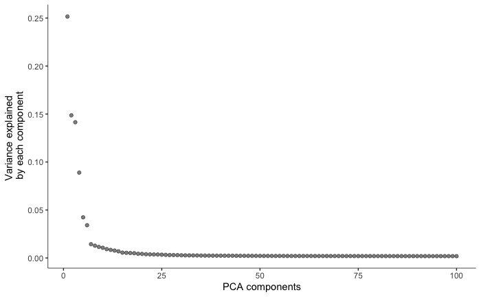

```r
## extract data from Seurat
seurat.object.all <- tenx.mutant.integrated
# counts
data <- as(as.matrix(GetAssayData(seurat.object.all, assay = "integrated", slot = "data")), 'sparseMatrix')
# meta data
pd <- data.frame(seurat.object.all@meta.data)

## keep only the columns that are relevant
#pData <- pd %>% select(orig.ident, nCount_RNA, nFeature_RNA)
## add gene short name
fData <- data.frame(gene_short_name = row.names(data), row.names = row.names(data))

## Construct monocle cds
monocle.object.all <- new_cell_data_set(expression_data = data, cell_metadata = pd, gene_metadata = fData)
## preprocess
monocle.object.all = preprocess_cds(monocle.object.all, num_dim = 100, norm_method = "none")
## plot variance explained plot
plot_pc_variance_explained(monocle.object.all)
```

```
No trajectory to plot. Has learn_graph() been called yet?
cluster not found in colData(cds), cells will not be colored
cluster_cells() has not been called yet, can't color cells by cluster
```

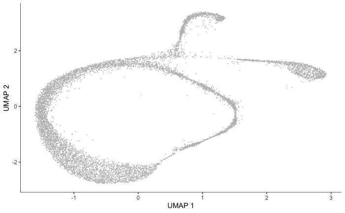

```r
## make monocle UMAP
#monocle.object.all = reduce_dimension(monocle.object.all, reduction_method = "UMAP", preprocess_method = "PCA", umap.metric = "euclidean", umap.n_neighbors = 20, umap.min_dist = 0.5, verbose = FALSE)
#plot_cells(monocle.object.all)

## add UMAP from Seurat
monocle.object.all@int_colData@listData$reducedDims@listData[["UMAP"]] <-seurat.object.all@reductions[["DIM_UMAP"]]@cell.embeddings
plot_cells(monocle.object.all)
```

```
No trajectory to plot. Has learn_graph() been called yet?
The `add` argument of `group_by()` is deprecated as of dplyr 1.0.0.
Please use the `.add` argument instead.
```

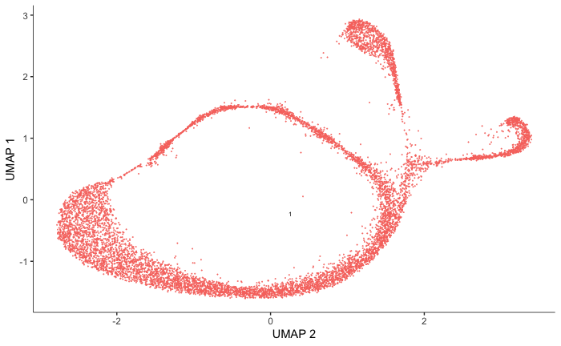

```r
## cluster
monocle.object.all = cluster_cells(monocle.object.all)

## plot clusters
plot_cells(monocle.object.all, color_cells_by="partition", group_cells_by="partition",  x = 2, y = 1)
```

```r
## reduce partitions to 1
monocle.object.all@clusters$UMAP$partitions[monocle.object.all@clusters$UMAP$partitions == "2"] <- "1"

#map pseudotime
monocle.object.all = learn_graph(monocle.object.all, learn_graph_control=list(ncenter=500), use_partition = FALSE)
plot_cells(monocle.object.all, color_cells_by="partition", group_cells_by="partition",  x = 2, y = 1)
```

```
`select_()` is deprecated as of dplyr 0.7.0.
Please use `select()` instead.
```

[output not shown]

[figure not shown]

```r
## a helper function to identify the root principal points:
## make cluster 2 the root
get_earliest_principal_node <- function(cds, time_bin="7"){
  cell_ids <- which(colData(cds)[, "seurat_clusters"] == time_bin)
  closest_vertex <-
  cds@principal_graph_aux[["UMAP"]]$pr_graph_cell_proj_closest_vertex
  closest_vertex <- as.matrix(closest_vertex[colnames(cds), ])
  root_pr_nodes <-
  igraph::V(principal_graph(cds)[["UMAP"]])$name[as.numeric(names
  (which.max(table(closest_vertex[cell_ids,]))))]

  root_pr_nodes
}

## calculate pseudotime
#monocle.object.all = order_cells(monocle.object.all, root_pr_nodes=get_earliest_principal_node(monocle.object.all))
monocle.object.all = order_cells(monocle.object.all)
```

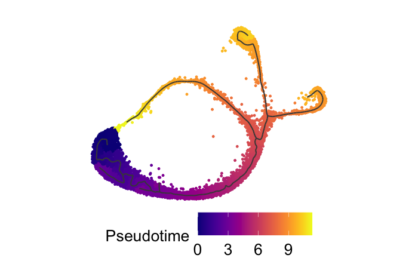

```r
## plot
umap_pt <- plot_cells(monocle.object.all, color_cells_by = "pseudotime", label_cell_groups=FALSE, cell_size = 1, x = 2, y = 1, label_branch_points=FALSE, label_leaves=FALSE, label_groups_by_cluster=FALSE, label_roots = FALSE) +
  coord_fixed() +
  theme_void() +
  labs(title = "") +
  theme(plot.title = element_text(hjust = 0.5, size=20), legend.position="bottom", legend.title=element_text (size=20), legend.text=element_text(size=20)) +
  guides(colour = guide_colourbar(barwidth = 10, barheight = 2, title = "Pseudotime"))

## view plot
umap_pt
```

```r
## help was obtained from here
## https://github.com/satijalab/seurat/issues/1658
```

save

```r
ggsave("../images_to_export/pt_all_UMAP_pt.png", plot = umap_pt, device = "png", path = NULL, scale = 1, width = 20, height = 20, units = "cm", dpi = 300, limitsize = TRUE)
```

# gganimnate GIF

```r
anim <- p +
  transition_time(pt) +
  shadow_mark()

animate(anim, height = 3, width = 3, units = "in", res = 150)
```

[output not shown]

[output cut: 46 more lines]

[output not shown]

Save animation

```r
anim_save("animated_UMAP.gif", path = "../images_to_export/")
```

#### Add original pt values

```r
## extract pt values
pt_values <- as.data.frame(pseudotime(monocle.object.all, reduction_method = "UMAP"))

tenx.mutant.integrated <- AddMetaData(tenx.mutant.integrated, pt_values, "old_pt_values")
```

Save old modules

```r
write.csv(modules_df_original_10x_data_set, file = "../data_to_export/modules_df_original_10x_data_set.csv")
```

# dot plot of expression by pt

annotations for plot

```r
## create annotation of clusters for heatmap
cluster_anno <- data.frame(cluster = unique(as.data.frame(tenx.mutant.integrated@meta.data)$seurat_clusters))
row.names(cluster_anno) <- cluster_anno$cluster

## clusters were defined in the merge script earlier as:
male_clusters <- c("20", "17", "8", "18")
female_clusters <- c("23", "19", "21", "5")
asex_clusters <- c("6", "4", "9", "2", "1", "7", "0", "3", "12", "16", "10", "11", "24", "14", "15", "22", "25")
bipotential_clusters <- c("13")

## add identities to the column
cluster_anno$group <- NA
cluster_anno$group[which(cluster_anno$cluster %in% asex_clusters)] <- "Asexual"
cluster_anno$group[which(cluster_anno$cluster %in% male_clusters)] <- "Male"
cluster_anno$group[which(cluster_anno$cluster %in% female_clusters)] <- "Female"
cluster_anno$group[which(cluster_anno$cluster %in% bipotential_clusters)] <- "Committed"
cluster_anno <- cluster_anno[ , 2, drop = FALSE]
cluster_anno

## Make a df of meta data
## this is used later in the ridgeplots too
## extract pseudotime values
pt_values <- as.data.frame(tenx.mutant.integrated@meta.data$old_pt_values)
pt_values$cell_name <- rownames(tenx.mutant.integrated@meta.data)
meta_data_df <- as.data.frame(tenx.mutant.integrated@meta.data)
meta_data_df$cell_name <- rownames(meta_data_df)
meta_data_df <- merge(meta_data_df, pt_values, by = "cell_name")
## the pt will be added to the last column so add the name pt to the merged df
names(meta_data_df)[length(names(meta_data_df))] <- "pt"

## add median pseudotime per cluster
## help was obtained here:https://stackoverflow.com/questions/54360855/calculate-mean-for-column-grouped-by-values-of-two-other-columns
## make subsetted dataframe with just cluster and pt
df_median_pt <- meta_data_df[ ,c("pt", "seurat_clusters")]
## apply across dataframe to get median
mean.df1 <- tapply(df_median_pt$pt, list(df_median_pt$seurat_clusters), median)
mean.df2 <- as.data.frame(as.table(mean.df1))
## rename cols
names(mean.df2) <- c("seurat_clusters", "pt_Median")
## rename rows
rownames(mean.df2) <- mean.df2$seurat_clusters
## to make each value have the mean in the original dataframe
#merge(df_median_pt, mean.df2)
## add to annotation dataframe
cluster_anno <- merge(cluster_anno, mean.df2, by=0)

## add rownames to dataframe
rownames(cluster_anno) <- cluster_anno$Row.names
## subset to have only info of interest
cluster_anno <- cluster_anno[,c(2,4)]
names(cluster_anno) <- c("Identity", "Median_Pseudotime_of_Cluster")

## this is for the rectangles on the plot below
## add an order column too:
my_levels <- c(asex_clusters, bipotential_clusters, male_clusters, female_clusters)
## order the annotation
cluster_anno <- cluster_anno[(match(my_levels, rownames(cluster_anno))), ]
## add label
cluster_anno$order <- c(1:nrow(cluster_anno))
## add coordinates for rectangles
cluster_anno$y1 <- cluster_anno$order-0.5
cluster_anno$y2 <- cluster_anno$order+0.5
cluster_anno$x1 <- 18
cluster_anno$x2 <- 18.5
## add coordinates for identity rectangles
cluster_anno$By1 <- cluster_anno$order-0.5
cluster_anno$By2 <- cluster_anno$order+0.5
cluster_anno$Bx1 <- 19
cluster_anno$Bx2 <- 19.5

## inspect
cluster_anno
```

plot

```r
## plot
dot_plot_paper_figure <- DotPlot(tenx.mutant.integrated,
                                 features = (c("PBANKA-1144800", "PBANKA-1435200", "PBANKA-1418100", "PBANKA-0902300", "PBANKA-1454800", "PBANKA-0828000", "PBANKA-0413400", "PBANKA-0716500", "PBANKA-0102400", "PBANKA-1447900", "PBANKA-1302700", "PBANKA-1437500", "PBANKA-0416100", "PBANKA-1300700", "PBANKA-0915000", "PBANKA-1443300", "PBANKA-1145900")), group.by = "seurat_clusters_plotting") +
  theme_classic() +
  ## change appearance and remove axis elements, and make room for arrows, and also change posoition of legends relative to one another
  theme(axis.text.x = element_text(size=20, angle = 45, hjust=1,vjust=1, family="Arial"), legend.position = "bottom", legend.direction = "horizontal", legend.box = "vertical", plot.margin = unit(c(1,3,1,3), "lines"), text=element_text(size=20, family="Arial"), axis.title=element_text(size=20,family="Arial")) +
  ##add these to above to remove y = plot.title = element_blank(), axis.text.y = element_blank(), axis.ticks.y = element_blank(), axis.title.y = element_blank()
  ## change the colours
  scale_colour_viridis(option = "inferno", guide = "colourbar", na.value="white", begin = 0, end = 1, direction = 1) +
  ## change x axis label
  labs(x = "Gene",  title = "", y = "Cluster") +
  ## annotate asex
  geom_hline(aes(yintercept = (length(asex_clusters)+0.5))) +
  ## annotate bipotential
  geom_hline(aes(yintercept = (length(c(asex_clusters, bipotential_clusters))+0.5))) +
  ## annotate sexes
  geom_hline(aes(yintercept = (length(c(asex_clusters, bipotential_clusters, male_clusters))+0.5))) +
  ## change label on bottom of plot so we can indicate markers
   scale_x_discrete(labels = ((c(expression(paste(italic("fd5"))),
    expression(paste(italic("fd4"))),
    expression(paste(italic("fd3"))),
    expression(paste(italic("fd2"))),
    expression(paste(italic("fd1"))),
    expression(paste(italic("gd1"))),
    expression(paste(italic("md5"))),
    expression(paste(italic("md4"))),
    expression(paste(italic("md3"))),
    expression(paste(italic("md2"))),
    expression(paste(italic("md1"))),
    expression(paste(italic("ap2-g"))),
    expression(paste(italic("dhc, putative"), "(male)")),
    expression(paste(italic("ccp1"), "(female)")),
    expression(paste(italic("ama1"), "(schizont)")),
    expression(paste(italic("msp9"), "(troph)")),
    expression(paste(italic("mahrp1b"), "(ring)"))))))  +
  ## add annotation on top of plot
  #geom_rect(aes(xmin = 0, xmax = 1), ymin = length(cluster_anno$Identity), ymax = length(cluster_anno$Identity) + 1) +
    ## flip coordinates
    geom_rect(data = cluster_anno, mapping=aes(xmin=x1, xmax=x2, ymin=y1, ymax=y2, fill=Median_Pseudotime_of_Cluster), inherit.aes = FALSE) +
    scale_fill_viridis_c(option = "plasma") +
  ## flip coordinates
  ## geoms below will use another color scale
    new_scale_fill() +
    geom_rect(data = cluster_anno, mapping=aes(xmin=Bx1, xmax=Bx2, ymin=By1, ymax=By2, fill=Identity), inherit.aes = FALSE) +
    scale_fill_manual(values = c("Male" ="#016c00", "Female"="#a52b1e", "Asexual"= "#0052c5", "Committed" = "#f2eb23")) +
    coord_flip()


## view
print(dot_plot_paper_figure)
```

save

```r
ggsave("../images_to_export/pt_all_dot_plot.png", plot = dot_plot_paper_figure, device = "png", path = NULL, scale = 1, width = 30, height = 35, units = "cm", dpi = 300, limitsize = TRUE)
```

WT only cells

```r
## select wt cells
all.wt.cells <- rownames(tenx.mutant.integrated@meta.data[which(tenx.mutant.integrated@meta.data$genotype_combined == "WT"), ])

## subset seurat
tenx.mutant.integrated.wt.only <- subset(tenx.mutant.integrated, cells = all.wt.cells)

##inspect
tenx.mutant.integrated.wt.only
```

```r
## plot
dot_plot_paper_figure_wt <- DotPlot(tenx.mutant.integrated.wt.only,
                                 features = (c("PBANKA-1144800", "PBANKA-1435200", "PBANKA-1418100", "PBANKA-0902300", "PBANKA-1454800", "PBANKA-0828000", "PBANKA-0413400", "PBANKA-0716500", "PBANKA-0102400", "PBANKA-1447900", "PBANKA-1302700", "PBANKA-1437500", "PBANKA-0416100", "PBANKA-1300700", "PBANKA-0915000", "PBANKA-1443300", "PBANKA-1145900")), group.by = "seurat_clusters_plotting", assay = "RNA") +
  theme_classic() +
  ## change appearance and remove axis elements, and make room for arrows, and also change posoition of legends relative to one another
  theme(axis.text.x = element_text(size=20, angle = 45, hjust=1,vjust=1, family="Arial"), axis.text.y = element_text(size=20, family="Arial"), legend.position = "bottom", legend.direction = "horizontal", legend.box = "vertical", plot.margin = unit(c(1,3,1,3), "lines"), text=element_text(size=24, family="Arial"), axis.title=element_text(size=20,family="Arial")) +
  ##add these to above to remove y = plot.title = element_blank(), axis.text.y = element_blank(), axis.ticks.y = element_blank(), axis.title.y = element_blank()
  ## change the colours
  scale_colour_viridis(option = "inferno", guide = "colourbar", na.value="white", begin = 0, end = 1, direction = 1) +
  ## change x axis label
  labs(x = "Gene",  title = "", y = "Cluster") +
  ## annotate asex
  geom_hline(aes(yintercept = (length(asex_clusters)+0.5))) +
  ## annotate bipotential
  geom_hline(aes(yintercept = (length(c(asex_clusters, bipotential_clusters))+0.5))) +
  ## annotate sexes
  geom_hline(aes(yintercept = (length(c(asex_clusters, bipotential_clusters, male_clusters))+0.5))) +
  ## change label on bottom of plot so we can indicate markers
   scale_x_discrete(labels = ((c(expression(paste(italic("fd5"))),
    expression(paste(italic("fd4"))),
    expression(paste(italic("fd3"))),
    expression(paste(italic("fd2"))),
    expression(paste(italic("fd1"))),
    expression(paste(italic("gd1"))),
    expression(paste(italic("md5"))),
    expression(paste(italic("md4"))),
    expression(paste(italic("md3"))),
    expression(paste(italic("md2"))),
    expression(paste(italic("md1"))),
    expression(paste(italic("ap2-g"))),
    expression(paste(italic("mg1"), "(male)")),
    expression(paste(italic("ccp1"), "(female)")),
    expression(paste(italic("ama1"), "(schizont)")),
    expression(paste(italic("msp9"), "(troph)")),
    expression(paste(italic("mahrp1b"), "(ring)"))))))  +
  ## add annotation on top of plot
  #geom_rect(aes(xmin = 0, xmax = 1), ymin = length(cluster_anno$Identity), ymax = length(cluster_anno$Identity) + 1) +
    ## flip coordinates
    geom_rect(data = cluster_anno, mapping=aes(xmin=x1, xmax=x2, ymin=y1, ymax=y2, fill=Median_Pseudotime_of_Cluster), inherit.aes = FALSE) +
    scale_fill_viridis_c(option = "plasma") +
  ## flip coordinates
  ## geoms below will use another color scale
    new_scale_fill() +
    geom_rect(data = cluster_anno, mapping=aes(xmin=Bx1, xmax=Bx2, ymin=By1, ymax=By2, fill=Identity), inherit.aes = FALSE) +
    scale_fill_manual(values = c("Male" ="#016c00", "Female"="#a52b1e", "Asexual"= "#0052c5", "Committed" = "#f2eb23")) +
    coord_flip()


## view
print(dot_plot_paper_figure_wt)
```

save

```r
ggsave("../images_to_export/pt_all_wt_dot_plot.png", plot = dot_plot_paper_figure_wt, device = "png", path = NULL, scale = 1, width = 30, height = 35, units = "cm", dpi = 300, limitsize = TRUE)
```

# 9. Save and Export

Save environment

```r
## This saves everything in the global environment for easy recall later
#save.image(file = "GCSKO_pseudotime_allcells.RData")
#load(file = "GCSKO_pseudotime_allcells.RData")
```

Save object(s)

```r
## save integrated object to file
saveRDS(tenx.mutant.integrated, file = "../data_to_export/tenx.mutant.integrated.RDS")
## restore the object
#tenx.mutant.integrated <- readRDS("../data_to_export/tenx.mutant.integrated.RDS")
```

# Appendix

## Acknowledgements

```r
## help was obtained from here to understand how to use integrated counts from Seurat (the short awnser is that we used non-integrated counts and only 10x for this part). It also contains some useful code that was used for extracting UMAP coordaintes.
## https://github.com/satijalab/seurat/issues/1658
```

After PT of all cells:

### Per branch analysis

```r
## access the closest principal graph node vertex for each cell and assign it as a column in your colData table using:
colData(monocle.object.all)$closest_vertex <- monocle.object.all@principal_graph_aux[["UMAP"]]$pr_graph_cell_proj_closest_vertex[,1]

plot_cells(monocle.object.all, color_cells_by = "closest_vertex", label_cell_groups = FALSE)

## then subset the usual way:
#monocle.object_male <- monocle.object[,colData(monocle.object)$closest_vertex %in% c(1, 2, 3)]
```

### Density Plots

```r
## load package to plot ridge plots
library(ggridges)

## extract pseudotime values:
pt_values <- as.data.frame(pseudotime(monocle.object.all, reduction_method = "UMAP"))
pt_values$cell_name <- rownames(pt_values)
meta_data_df <- as.data.frame(monocle.object.all@colData)
meta_data_df$cell_name <- rownames(meta_data_df)
meta_data_df <- merge(meta_data_df, pt_values, by = "cell_name")
names(meta_data_df)[128] <- "pt"

## define which clusters will be which identity
male_clusters <- c("45", "30", "42", "18", "25", "37", "32", "29")
female_clusters <- c("39", "40", "38", "10", "26", "19", "17", "36")
asex_clusters <- c("0", "22", "8", "1", "20", "2", "15", "6", "14", "12", "13", "23", "31", "21", "44", "33", "35", "28", "27", "34", "43", "41", "4", "16", "5", "11", "7", "11", "3", "9", "24")

## make a dataframe for just male cells:
male_cells_df <- meta_data_df[which(meta_data_df$seurat_clusters %in% male_clusters),]
female_cells_df <- meta_data_df[which(meta_data_df$seurat_clusters %in% female_clusters),]

ggplot(male_cells_df, aes(x = pt, y = reorder(identity_combined, pt, median), fill = stat(x))) +
  geom_density_ridges_gradient(scale = 3, rel_min_height = 0.01, jittered_points = TRUE, quantile_lines = TRUE, quantiles = 2, point_alpha = 0.5, alpha = 0.5) +
  scale_fill_viridis_c(name = "Pseudotime", option = "C") +
  labs(title = 'Male PT by genotype') +
  theme_classic()

ggplot(female_cells_df, aes(x = pt, y = reorder(identity_combined, pt, median), fill = stat(x))) +
  geom_density_ridges_gradient(scale = 3, rel_min_height = 0.01, jittered_points = TRUE, quantile_lines = TRUE, quantiles = 2) +
  scale_fill_viridis_c(name = "Pseudotime", option = "C") +
  labs(title = 'Female PT by genotype') +
  theme_classic()
```

ComplexHeatmap version

```r
library(ComplexHeatmap)
library(RColorBrewer)

## pheatmap calculates Z scores for plotting values
scale_matrix_by_cols <- function (x)
{
    m = apply(x, 1, mean, na.rm = T)
    s = apply(x, 1, sd, na.rm = T)
    return((x - m)/s)
}
## calculate z score by col
agg_mat_df_scaled <- t(as.matrix(scale_matrix_by_cols(t(agg_mat_df))))

## add annotation:
heatmap_annotation <- HeatmapAnnotation(df = cluster_anno,
                                        col = list(
Identity = c(Male="#016c00", Female="#a52b1e", Asexual= "#0052c5", Committed = "#f2eb23")),
                                        annotation_legend_param = list(Median_Pseudotime_of_Cluster = list(direction = "horizontal"), Identity = list(nrow = 1)))

## plot
modules_heatmap <- Heatmap(agg_mat_df_scaled,
        column_order = NULL,
        clustering_method_rows = "ward.D2",
        bottom_annotation = heatmap_annotation,
        col = colorRampPalette(rev(brewer.pal(n = 7, name =
  "RdYlBu")))(100),
        heatmap_legend_param = list(direction = "horizontal"))
draw(modules_heatmap, merge_legend = TRUE, heatmap_legend_side = "bottom",
    annotation_legend_side = "bottom")

## https://www.biostars.org/p/380544/
```